# R Notebook

```r
library(Seurat)
library(ggplot2)
library(hdf5r)
library(here)
library(clustree)

here::i_am("notebooks/02_exploration_19H1257.Rmd")

# Path to the Space Ranger output for sample 19B5776
# This directory contains :
#     - filtered_feature_bc_matrix.h5 : filtered gene expression matrix
#     - spatial/ : tissue images and spatial coordinates

sample_path <- here("data",
"raw",
"19h1257-1_STonly",
"19h1257-1_v3"
)

## Loading data the 10x Vasium data into a Seurat object
## Argument explanation :
#   - data_dir : directory containing the .h5 expression matrix
#   - filename : Filtered gene expression matrix generated by Space Ranger (rows : genes, columns : Vasium sports )
#   - assay : name of the assay that will store the spatial gene expression data in the Seurat Object
#   - slice : Identifier assigned to this tissue section/image

hnscc_19 <- Load10X_Spatial(
  data.dir = sample_path,
  filename = "filtered_feature_bc_matrix.h5",
  assay = "Spatial",
  slice = "19H1257"
)

# General summary
hnscc_19
```

```
An object of class Seurat
18085 features across 2216 samples within 1 assay
Active assay: Spatial (18085 features, 0 variable features)
 1 layer present: counts
 1 spatial field of view present: X19H1257
```

```r
# Number of genes and spatial spots
dim(hnscc_19)
```

```
[1] 18085  2216
```

```r
# Available assays
Assays(hnscc_19)
```

```
[1] "Spatial"
```

```r
# Available tissue image
Images(hnscc_19)
```

```
[1] "X19H1257"
```

```r
# Metadata associated with the first spots

head(hnscc_19[[]])
```

|  | orig.ident | nCount_Spatial | nFeature_Spatial |
| --- | --- | --- | --- |
| AACACTTGGCAAGGAA-1 | SeuratProject | 33854 | 7658 |
| AACAGGATTCATAGTT-1 | SeuratProject | 13670 | 6071 |
| AACAGGTTCACCGAAG-1 | SeuratProject | 23768 | 7798 |
| AACATACTCATATGCG-1 | SeuratProject | 16108 | 5865 |
| AACATAGTCTATCTAC-1 | SeuratProject | 16263 | 6579 |
| AACATCTAATGACCGG-1 | SeuratProject | 32710 | 8926 |

```r
Project(hnscc_19) <- "19H1257"

hnscc_19$orig.ident <- "19H1257"

head(hnscc_19[[]])
```

|  | orig.ident | nCount_Spatial | nFeature_Spatial |
| --- | --- | --- | --- |
| AACACTTGGCAAGGAA-1 | 19H1257 | 33854 | 7658 |
| AACAGGATTCATAGTT-1 | 19H1257 | 13670 | 6071 |
| AACAGGTTCACCGAAG-1 | 19H1257 | 23768 | 7798 |
| AACATACTCATATGCG-1 | 19H1257 | 16108 | 5865 |
| AACATAGTCTATCTAC-1 | 19H1257 | 16263 | 6579 |
| AACATCTAATGACCGG-1 | 19H1257 | 32710 | 8926 |

```r
# we add sample id for downstream analysis
hnscc_19$sample_id <- "19H1257"


# Numerical summary of total transcript count per spot (UMI)

summary(hnscc_19$nCount_Spatial)
```

```
   Min. 1st Qu.  Median    Mean 3rd Qu.    Max.
     28   13176   19199   19508   24428   68366
```

```r
# Numerical summary of total features: number of detected genes per spot
summary(hnscc_19$nFeature_Spatial)
```

```
   Min. 1st Qu.  Median    Mean 3rd Qu.    Max.
     28    5594    6870    6404    7667   10260
```

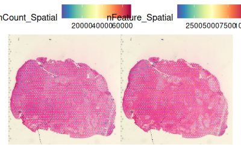

```r
# Visualize the spatial distribution of QC metrics

SpatialFeaturePlot(hnscc_19,
                   features = c("nCount_Spatial", "nFeature_Spatial"), ncol=2 )
```

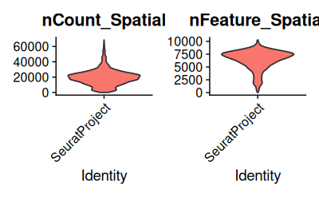

```r
VlnPlot(hnscc_19, features = c("nCount_Spatial", "nFeature_Spatial"), pt.size = 0, ncol = 2)
```

```r
NA
NA
```

**Figure – Distribution of spatial QC metrics for sample 19H1257.**  
Violin plots show the distribution of total transcript counts and the number of detected genes across the 2,216 spatial spots.

### Distribution of transcript counts and detected genes

The distribution of total transcript counts per spot (`nCount_Spatial`) is centered around approximately 19,000 transcripts, with most spots ranging between about 13,000 and 24,000 transcripts.

A smaller population of spots shows substantially lower transcript counts, including a few spots with values close to zero. Conversely, a limited number of spots display high transcript counts, reaching approximately 68,000 transcripts.

The number of detected genes per spot (`nFeature_Spatial`) is generally high, with a median of approximately 6,870 genes. Most spots contain between approximately 5,600 and 7,700 detected genes.

A lower tail is nevertheless visible in the distribution, indicating the presence of a small subset of spots with reduced transcriptomic complexity.

At this stage, these low-count or low-feature spots are not removed automatically. Their spatial localization must first be examined to determine whether they correspond to tissue boundaries, specific histological regions, or potential technical artifacts.

```r
summary(hnscc_19$nCount_Spatial)
```

```
   Min. 1st Qu.  Median    Mean 3rd Qu.    Max.
     28   13176   19199   19508   24428   68366
```

```r
summary(hnscc_19$nFeature_Spatial)
```

```
   Min. 1st Qu.  Median    Mean 3rd Qu.    Max.
     28    5594    6870    6404    7667   10260
```

```r
quantile(
  hnscc_19$nCount_Spatial,
  probs = c(0.01, 0.05, 0.10, 0.25, 0.50, 0.75, 0.90, 0.95, 0.99)
)
```

```
      1%       5%      10%      25%      50%      75%      90%      95%      99%
 1318.55  3597.75  6691.00 13176.00 19199.00 24428.25 30339.50 36189.50 52774.10
```

```r
quantile(
  hnscc_19$nFeature_Spatial,
  probs = c(0.01, 0.05, 0.10, 0.25, 0.50, 0.75, 0.90, 0.95, 0.99)
)
```

```
     1%      5%     10%     25%     50%     75%     90%     95%     99%
1012.15 2287.50 3695.00 5593.75 6870.00 7667.00 8213.00 8545.25 9254.30
```

```r
low_feature_threshold <- quantile(hnscc_19$nFeature_Spatial, 0.05)

low_feature_threshold
```

```
    5%
2287.5
```

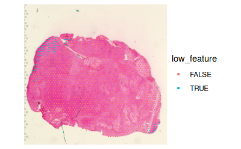

```r
hnscc_19$low_feature <- hnscc_19$nFeature_Spatial < low_feature_threshold

SpatialDimPlot(
  hnscc_19, group.by = "low_feature"
)
```

### Spatial localization of low-feature spots

Spots belonging to the lowest 5% of the `nFeature_Spatial` distribution were projected onto the tissue section.

Most low-feature spots were located along the outer tissue boundaries, particularly at the left and right edges of the section. Only a limited number of low-feature spots were observed within the central tissue area.

This spatial pattern suggests that the reduced transcriptomic complexity may partly result from incomplete tissue coverage or lower cellular density at the tissue margins, rather than from a widespread technical failure.

Therefore, these spots are retained at this stage, and no filtering threshold is applied solely based on the 5th percentile of `nFeature_Spatial`.

```r
Idents(hnscc_19) <- "sample_id"


hnscc_19[["percent.mt"]] <- PercentageFeatureSet(
  object = hnscc_19,
  pattern = "^MT-",
  assay = "Spatial"
)

# Numerical Summary
summary(hnscc_19$percent.mt)
```

```
   Min. 1st Qu.  Median    Mean 3rd Qu.    Max.
  0.000   1.377   2.011   1.941   2.497   4.035
```

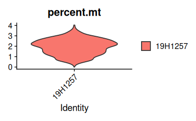

```r
# Distribution across all spots
VlnPlot(
  hnscc_19,
  features = "percent.mt",
  pt.size = 0
)
```

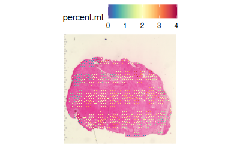

```r
SpatialFeaturePlot(
  hnscc_19,
  features = "percent.mt"
)
```

```r
# Numerical summary of mitochondrial transcript percentages
summary(hnscc_19$percent.mt)
```

```
   Min. 1st Qu.  Median    Mean 3rd Qu.    Max.
  0.000   1.377   2.011   1.941   2.497   4.035
```

```r
# Detailed percentiles
quantile(
  hnscc_19$percent.mt,
  probs = c(
    0,
    0.01,
    0.05,
    0.25,
    0.50,
    0.75,
    0.95,
    0.99,
    1
  )
)
```

```
       0%        1%        5%       25%       50%       75%       95%       99%      100%
0.0000000 0.4307379 0.6729057 1.3770480 2.0112713 2.4974989 3.0728307 3.4898990 4.0347272
```

```r
# Identify spots above the candidate mitochondrial threshold
hnscc_19$high_mt <- hnscc_19$percent.mt >= 10

table(hnscc_19$high_mt)
```

```
FALSE
 2216
```

```r
prop.table(
  table(hnscc_19$high_mt)
)
```

```
FALSE
    1
```

### Mitochondrial transcript assessment

The mitochondrial transcript percentage was low across sample 19H1257.

None of the 2,216 spatial spots exceeded the 10% mitochondrial threshold. Therefore, no spot would be removed based on mitochondrial transcript content.

This result suggests that elevated mitochondrial expression is not a major quality concern for this sample.

```r
sum(hnscc_19$nFeature_Spatial <= 200)
```

```
[1] 1
```

```r
mean(hnscc_19$nFeature_Spatial <= 200 )
```

```
[1] 0.0004512635
```

| metric | value |
| --- | --- |
| Genes before QC | 18085 |
| Genes after QC | 18085 |
| Spots before QC | 2216 |
| Spots after QC | 2215 |
| Genes removed | 0 |
| Spots removed | 1 |

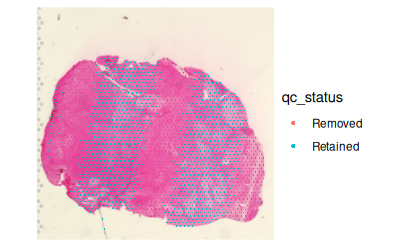

```r
# Label spots according to their QC status
hnscc_19$qc_status <- ifelse(
  colnames(hnscc_19) %in% colnames(hnscc_19_qc),
  "Retained",
  "Removed"
)

# Visualize the location of removed spots
SpatialDimPlot(
  hnscc_19,
  group.by = "qc_status"
)
```

### Final quality-control filtering

Spot-level quality-control filtering retained 2215 of the initial 2216 spatial spots.

Only 1 spot was removed because it contained 200 or fewer detected genes. No spot was excluded based on mitochondrial transcript content, as all spots had a mitochondrial percentage below 10%.

Overall, the QC procedure had a minimal effect on the number of spatial spots, indicating good overall data quality for sample 19H1257.

```r
# Normalize spatial gene expression data using SCTransform

hnscc_19_sct <- SCTransform(
  hnscc_19_qc,
  assay = "Spatial",
  verbose = FALSE,
  return.only.var.genes = TRUE
)

# Inspect the normalized Seurat object
hnscc_19_sct
```

```
An object of class Seurat
36030 features across 2215 samples within 2 assays
Active assay: SCT (17945 features, 3000 variable features)
 3 layers present: counts, data, scale.data
 1 other assay present: Spatial
 1 spatial field of view present: X19H1257
```

```r
# Check available assays
Assays(hnscc_19_sct)
```

```
[1] "Spatial" "SCT"
```

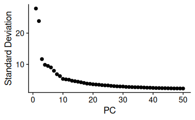